# Trade Count Regression - One Model

Tobi Bosede

December 15, 2016

550.700

```r
library(mgcv)
library(ggplot2)
```

```r
setwd("C:/Users/aniverb/Documents/Grad_School/JHU/700")
trade_data=read.table("trades_count_regression_2016-11-18.txt", header=T)
head(trade_data)
```

```
##   ProductName   Maturity       Date TimeToMaturity DayOfTheWeek DayofMonth
## 1          6E 2016-06-13 2016-05-02             42          Mon          2
## 2          6E 2016-06-13 2016-05-03             41          Tue          3
## 3          6E 2016-06-13 2016-05-04             40          Wed          4
## 4          6E 2016-06-13 2016-05-05             39          Thu          5
## 5          6E 2016-06-13 2016-05-06             38          Fri          6
## 6          6E 2016-06-13 2016-05-09             35          Mon          9
##   ProductType Day DayTradeTotal TradeTotBCTrans TradeTotLogTrans
## 1          FX   1        105173        17.03472         11.56336
## 2          FX   2        137646        17.59816         11.83244
## 3          FX   3        135657        17.56743         11.81788
## 4          FX   4        126798        17.42525         11.75035
## 5          FX   5        147658        17.74676         11.90265
## 6          FX   6         57764        15.81382         10.96412
```

```r
#use only half of data randomly split into train and test
n=dim(trade_data)[1]/2
reg_data=trade_data[1:n, ]
set.seed(12-1-16)
train_id=sample(1:n, n)[1:floor(n/2)]
train=reg_data[train_id, ]
test=reg_data[-train_id, ]
```

Build linear regression model with penalized cubic spline. Spline parameters found by cross validation.

```r
model1 <- gam(TradeTotBCTrans ~ s(TimeToMaturity, bs="cr") + s(DayofMonth, bs="cr") + s(Day, bs="cr") + factor(ProductType) + factor(ProductName) + factor(DayOfTheWeek), family=gaussian(), data = train, method="GCV.Cp", select=TRUE)
summary(model1)
```

```
##
## Family: gaussian
## Link function: identity
##
## Formula:
## TradeTotBCTrans ~ s(TimeToMaturity, bs = "cr") + s(DayofMonth,
##     bs = "cr") + s(Day, bs = "cr") + factor(ProductType) + factor(ProductName) +
##     factor(DayOfTheWeek)
##
## Parametric coefficients:
##                            Estimate Std. Error t value Pr(>|t|)
## (Intercept)                9.169616   0.152286  60.213  < 2e-16 ***
## factor(ProductType)Bond    0.415604   0.107139   3.879 0.000108 ***
## factor(ProductType)Energy  1.590301   0.116801  13.615  < 2e-16 ***
## factor(ProductType)FX      2.419596   0.227928  10.616  < 2e-16 ***
## factor(ProductType)Index   2.558195   0.122717  20.846  < 2e-16 ***
## factor(ProductType)Metal   0.332031   0.105386   3.151 0.001651 **
## factor(ProductName)CL      1.549779   0.188536   8.220 3.45e-16 ***
## factor(ProductName)ES      3.151000   0.190716  16.522  < 2e-16 ***
## factor(ProductName)GC      0.332031   0.105386   3.151 0.001651 **
## factor(ProductName)GE      1.179525   0.360545   3.272 0.001087 **
## factor(ProductName)HO      0.415604   0.107139   3.879 0.000108 ***
## factor(ProductName)KE      1.853889   0.243726   7.606 4.17e-14 ***
## factor(ProductName)NG      0.999805   0.171801   5.820 6.78e-09 ***
## factor(ProductName)NQ     -0.592805   0.203748  -2.909 0.003657 **
## factor(ProductName)RB     -0.959283   0.255686  -3.752 0.000180 ***
## factor(DayOfTheWeek)Mon   -0.354076   0.247920  -1.428 0.153381
## factor(DayOfTheWeek)Thu    0.004009   0.239561   0.017 0.986648
## factor(DayOfTheWeek)Tue    0.243760   0.235366   1.036 0.300474
## factor(DayOfTheWeek)Wed    0.217136   0.236935   0.916 0.359539
## ---
## Signif. codes:  0 '***' 0.001 '**' 0.01 '*' 0.05 '.' 0.1 ' ' 1
##
## Approximate significance of smooth terms:
##                     edf Ref.df       F  p-value
## s(TimeToMaturity) 8.312      9 180.904  < 2e-16 ***
## s(DayofMonth)     3.521      9   0.712   0.0812 .
## s(Day)            7.804      9   4.621 4.21e-07 ***
## ---
## Signif. codes:  0 '***' 0.001 '**' 0.01 '*' 0.05 '.' 0.1 ' ' 1
##
## Rank: 41/46
## R-sq.(adj) =   0.49   Deviance explained = 49.7%
## GCV = 12.392  Scale est. = 12.203    n = 2206
```

The model is not very good as the Adjust R sq is barely .5 as well, only about half of the deviance/variation is explained.

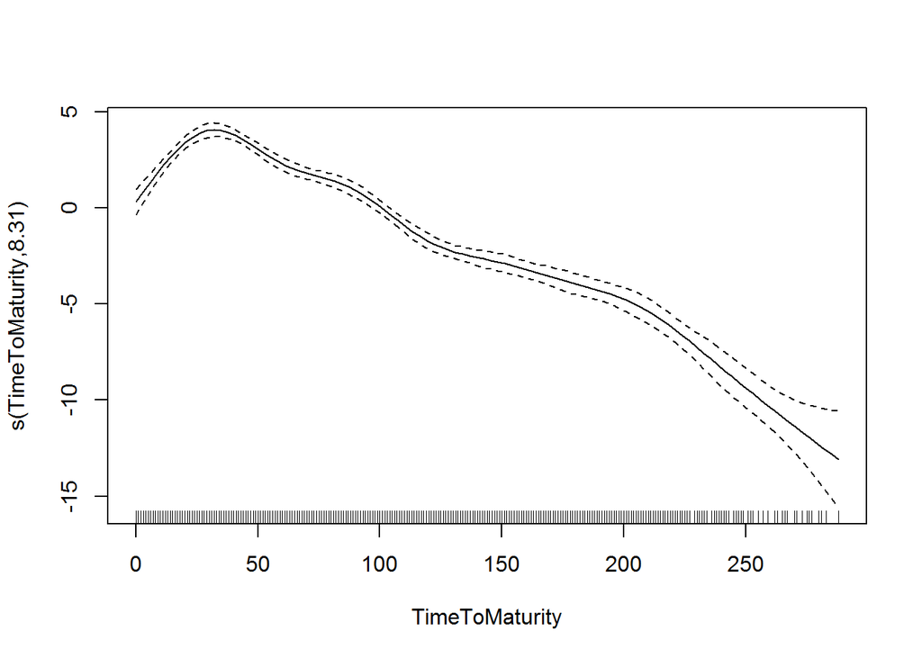

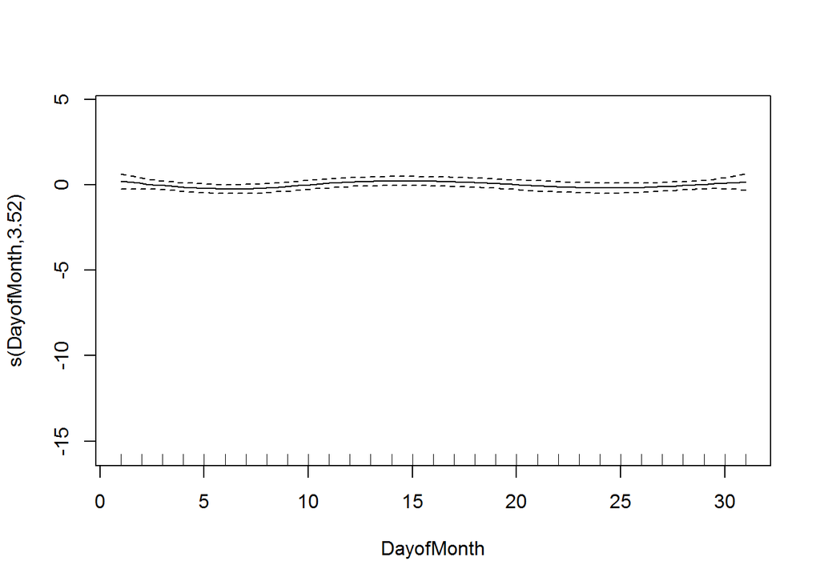

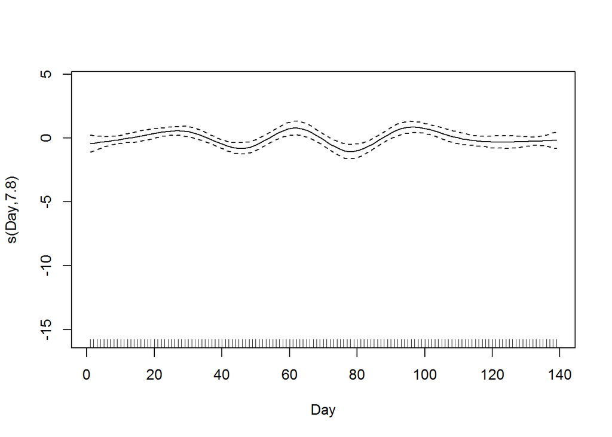

```r
plot(model1)
```

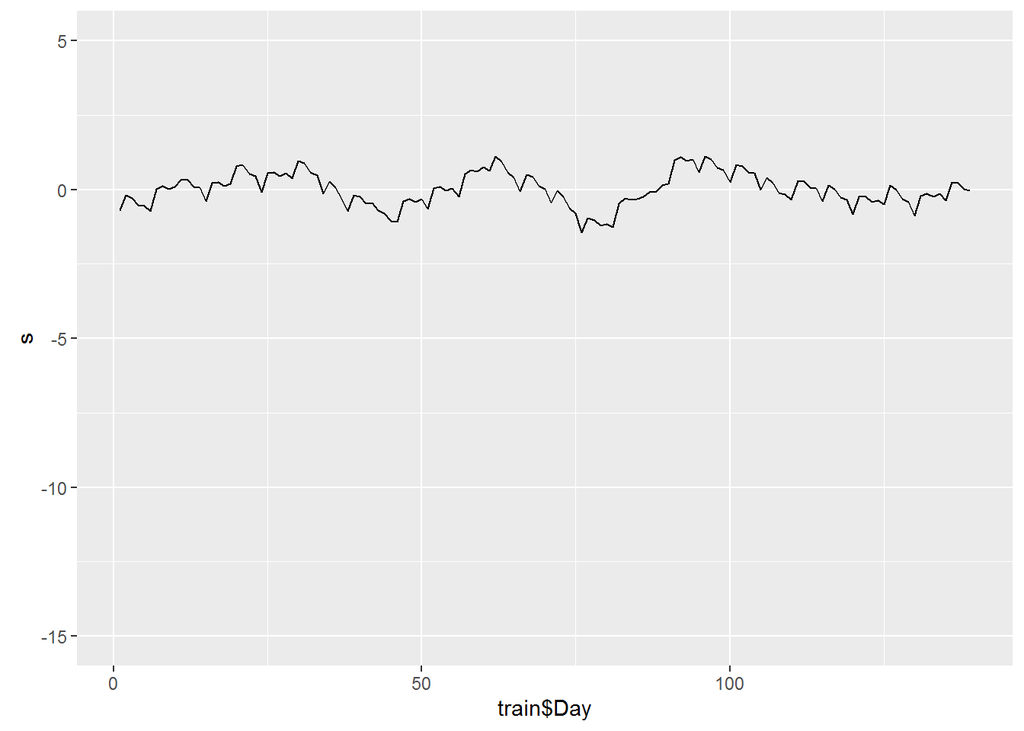

```r
p <- predict(model1, type="lpmatrix")
beta <- coef(model1)[grepl("Day", names(coef(model1)))]
s <- p[,grepl("Day", colnames(p))] %*% beta
ggplot(data=cbind.data.frame(s, train$Day), aes(x=train$Day, y=s, ymin = -15, ymax = 5)) + geom_line()
```

Dips occur on Mondays and peaks on Tuesdays.

```r
optFrame=cbind.data.frame(s, train)
sub=subset(optFrame, train$Day<50)
which(sub$s==min(sub$s))
```

```
##  [1]  22  31  84 150 242 315 348 392 409 416 552 693 730 857 949
```

```r
sub[22,]
```

```
##              s ProductName   Maturity       Date TimeToMaturity
## 3240 -1.072167          NG 2016-07-27 2016-07-11             16
##      DayOfTheWeek DayofMonth ProductType Day DayTradeTotal TradeTotBCTrans
## 3240          Mon         11      Energy  46         88238        16.67221
##      TradeTotLogTrans
## 3240         11.38779
```

```r
sub=subset(optFrame, 50<train$Day & train$Day<75)
which(sub$s==max(sub$s))
```

```
##  [1]  28  40  41  74  83 102 121 149 151 152 170 252 255
```

```r
sub[28,]
```

```
##             s ProductName   Maturity       Date TimeToMaturity
## 3388 1.113802          NG 2016-09-28 2016-08-02             57
##      DayOfTheWeek DayofMonth ProductType Day DayTradeTotal TradeTotBCTrans
## 3388          Tue          2      Energy  62         15416        13.28031
##      TradeTotLogTrans
## 3388         9.643161
```

```r
sub=subset(optFrame, 75<train$Day & train$Day<100)
which(sub$s==min(sub$s))
```

```
##  [1]  45  48  54 151 184 212 226 249 271 287 289
```

```r
sub[45,]
```

```
##              s ProductName   Maturity       Date TimeToMaturity
## 4044 -1.445975          NQ 2016-12-16 2016-08-22            116
##      DayOfTheWeek DayofMonth ProductType Day DayTradeTotal TradeTotBCTrans
## 4044          Mon         22       Index  76            13        2.784466
##      TradeTotLogTrans
## 4044         2.564949
```

```r
which(sub$s==max(sub$s))
```

```
##  [1]  57  79  89  99 122 149 228 246 257 270 285 293 295 314 326 346
```

```r
sub[57,]
```

```
##            s ProductName   Maturity       Date TimeToMaturity DayOfTheWeek
## 594 1.118623          CL 2016-09-20 2016-09-20              0          Tue
##     DayofMonth ProductType Day DayTradeTotal TradeTotBCTrans
## 594         20      Energy  96          8507        12.20726
##     TradeTotLogTrans
## 594         9.048645
```

Consistent with model coefficients but inconsistent with median of entire data. Due to sampling? More samples for Wed in entire data than in sample.

```r
test=subset(optFrame, train$DayOfTheWeek=="Mon")
dim(test)
```

```
## [1] 396  12
```

```r
test=subset(optFrame, train$DayOfTheWeek=="Tue")
dim(test)
```

```
## [1] 483  12
```

```r
test=subset(optFrame, train$DayOfTheWeek=="Wed")
dim(test)
```

```
## [1] 468  12
```

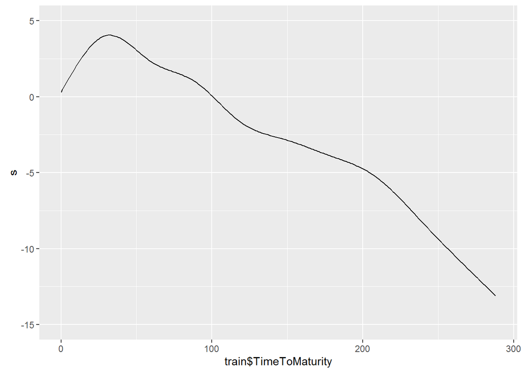

```r
beta <- coef(model1)[grepl("TimeToMaturity", names(coef(model1)))]
s <- p[,grepl("TimeToMaturity", colnames(p))] %*% beta
ggplot(data=cbind.data.frame(s, train$TimeToMaturity), aes(x=train$TimeToMaturity, y=s, ymin = -15, ymax = 5)) + geom_line()
```

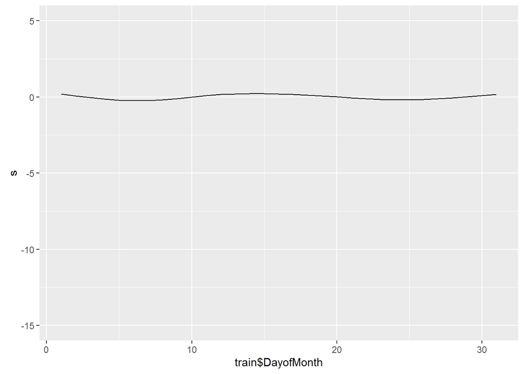

```r
beta <- coef(model1)[grepl("DayofMonth", names(coef(model1)))]
s <- p[,grepl("DayofMonth", colnames(p))] %*% beta
ggplot(data=cbind.data.frame(s, train$DayofMonth), aes(x=train$DayofMonth, y=s, ymin = -15, ymax = 5)) + geom_line()
```

```r
model1$coefficients
```

```
##               (Intercept)   factor(ProductType)Bond
##                9.16961614                0.41560403
## factor(ProductType)Energy     factor(ProductType)FX
##                1.59030070                2.41959615
##  factor(ProductType)Index  factor(ProductType)Metal
##                2.55819468                0.33203150
##     factor(ProductName)CL     factor(ProductName)ES
##                1.54977878                3.15099983
##     factor(ProductName)GC     factor(ProductName)GE
##                0.33203150                1.17952454
##     factor(ProductName)HO     factor(ProductName)KE
##                0.41560403                1.85388908
##     factor(ProductName)NG     factor(ProductName)NQ
##                0.99980538               -0.59280515
##     factor(ProductName)RB   factor(DayOfTheWeek)Mon
##               -0.95928346               -0.35407577
##   factor(DayOfTheWeek)Thu   factor(DayOfTheWeek)Tue
##                0.00400945                0.24375997
##   factor(DayOfTheWeek)Wed       s(TimeToMaturity).1
##                0.21713631                3.88992187
##       s(TimeToMaturity).2       s(TimeToMaturity).3
##                2.20668257                0.87852570
##       s(TimeToMaturity).4       s(TimeToMaturity).5
##               -1.74827749               -2.88458479
##       s(TimeToMaturity).6       s(TimeToMaturity).7
##               -3.92426288               -5.23865620
##       s(TimeToMaturity).8       s(TimeToMaturity).9
##               -8.27288136              -13.09907422
##           s(DayofMonth).1           s(DayofMonth).2
##               -0.22612788               -0.27301581
##           s(DayofMonth).3           s(DayofMonth).4
##                0.03078245                0.15074996
##           s(DayofMonth).5           s(DayofMonth).6
##                0.08203797               -0.10893537
##           s(DayofMonth).7           s(DayofMonth).8
##               -0.23597079               -0.13165671
##           s(DayofMonth).9                  s(Day).1
##                0.15414110                0.36403873
##                  s(Day).2                  s(Day).3
##                0.55575634               -0.65331585
##                  s(Day).4                  s(Day).5
##                0.87716884               -0.96289130
##                  s(Day).6                  s(Day).7
##                0.87454334                0.22289518
##                  s(Day).8                  s(Day).9
##               -0.18399838               -0.11422933
```

```r
model1$sp #spline parameters
```

```
## s(TimeToMaturity)1 s(TimeToMaturity)2     s(DayofMonth)1
##       1.117997e-01       7.579374e-02       7.085191e+00
##     s(DayofMonth)2            s(Day)1            s(Day)2
##       7.125255e+10       3.485377e-02       7.856905e+09
```

Unsurprisingly, the below residuals are quite large, especially since they are for the box cox transformed trade counts. However they seem constant so an assumption of the linear regression model is fufilled.

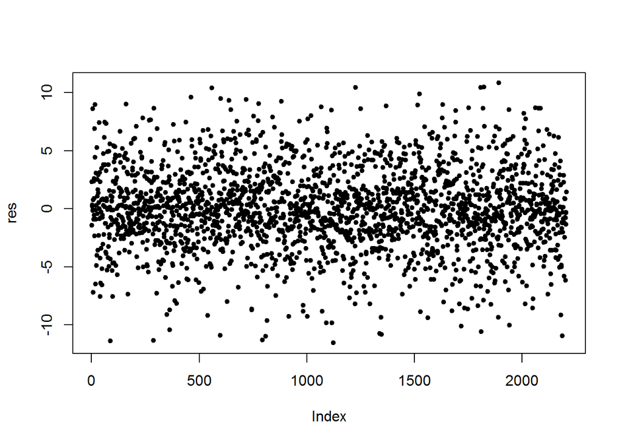

```r
res=model1$residuals
plot(res, pch=20)
```

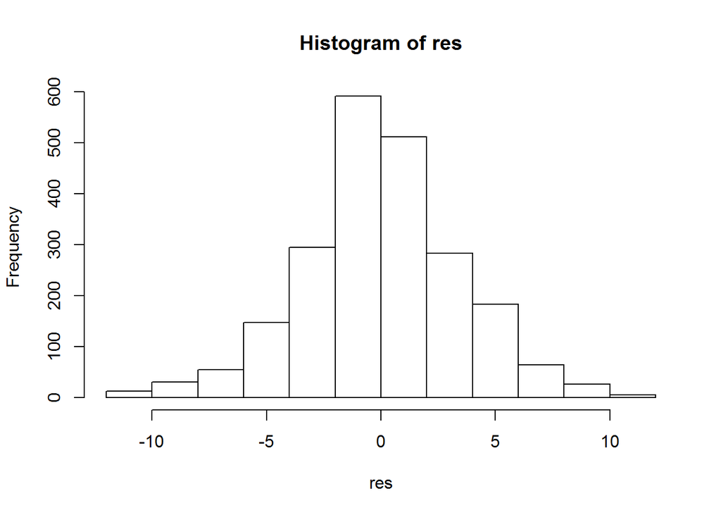

```r
hist(res)
```

Actual values are black, predicted values are red

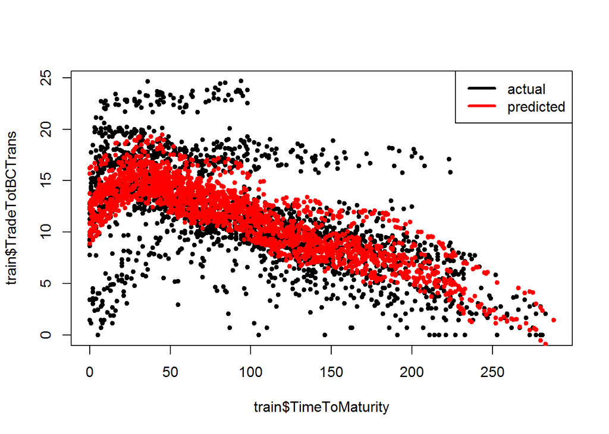

```r
trainPred=model1$fitted.values

plot(train$TimeToMaturity, train$TradeTotBCTrans, pch=20)
points(train$TimeToMaturity, trainPred, col="red", pch=20)
legend("topright", c("actual", "predicted"),lwd=c(3,3),col=c("black", "red"))
```

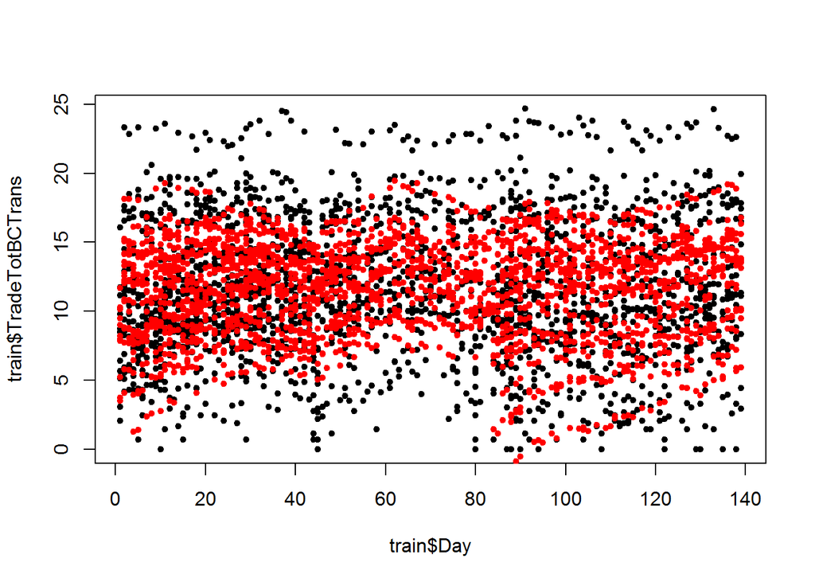

```r
plot(train$Day, train$TradeTotBCTrans, pch=20)
points(train$Day, trainPred, col="red", pch=20)
```

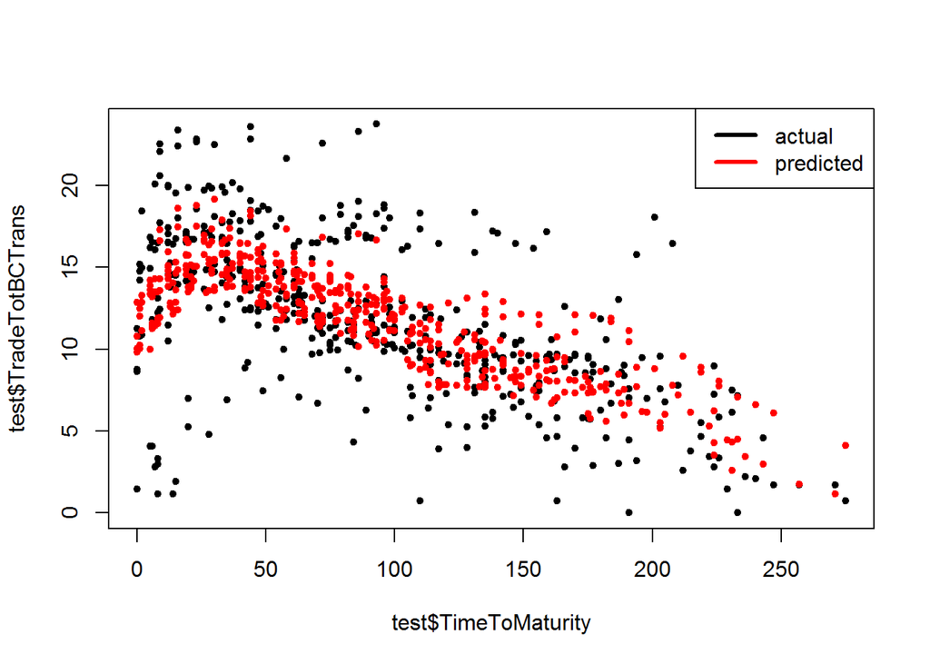

```r
testPred <- predict(model1, test)

plot(test$TimeToMaturity, test$TradeTotBCTrans, pch=20)
points(test$TimeToMaturity, testPred, col="red", pch=20)
legend("topright", c("actual", "predicted"),lwd=c(3,3),col=c("black", "red"))
```

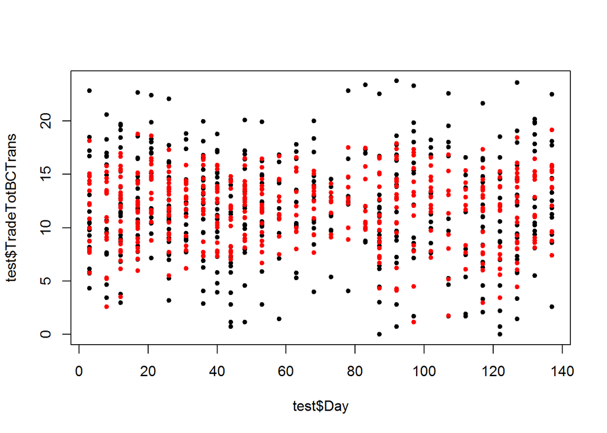

```r
plot(test$Day, test$TradeTotBCTrans, pch=20)
points(test$Day, testPred, col="red", pch=20)
```

Not significantly better than model 1

```r
#with day of month factored instead of splined(ceates a lot of addtl vars)
model2 <- gam(TradeTotBCTrans ~ s(TimeToMaturity, bs="cr") + s(Day, bs="cr") + factor(ProductType) + factor(ProductName) + factor(DayOfTheWeek) + factor(DayofMonth), family=gaussian(), data = train, method="GCV.Cp", select=TRUE)
summary(model2)
```

```
##
## Family: gaussian
## Link function: identity
##
## Formula:
## TradeTotBCTrans ~ s(TimeToMaturity, bs = "cr") + s(Day, bs = "cr") +
##     factor(ProductType) + factor(ProductName) + factor(DayOfTheWeek) +
##     factor(DayofMonth)
##
## Parametric coefficients:
##                            Estimate Std. Error t value Pr(>|t|)
## (Intercept)                9.489607   0.361729  26.234  < 2e-16 ***
## factor(ProductType)Bond    0.444348   0.113912   3.901 9.88e-05 ***
## factor(ProductType)Energy  1.643457   0.131903  12.460  < 2e-16 ***
## factor(ProductType)FX      2.489457   0.238414  10.442  < 2e-16 ***
## factor(ProductType)Index   2.619202   0.132397  19.783  < 2e-16 ***
## factor(ProductType)Metal   0.341815   0.112424   3.040 0.002391 **
## factor(ProductName)CL      1.564373   0.189606   8.251 2.71e-16 ***
## factor(ProductName)ES      3.171781   0.192983  16.436  < 2e-16 ***
## factor(ProductName)GC      0.341815   0.112424   3.040 0.002391 **
## factor(ProductName)GE      1.165801   0.360609   3.233 0.001244 **
## factor(ProductName)HO      0.444348   0.113912   3.901 9.88e-05 ***
## factor(ProductName)KE      1.951328   0.255487   7.638 3.31e-14 ***
## factor(ProductName)NG      1.029810   0.173853   5.923 3.66e-09 ***
## factor(ProductName)NQ     -0.552579   0.205461  -2.689 0.007212 **
## factor(ProductName)RB     -0.950726   0.258019  -3.685 0.000235 ***
## factor(DayOfTheWeek)Mon   -0.249428   0.257398  -0.969 0.332636
## factor(DayOfTheWeek)Thu    0.046683   0.243548   0.192 0.848012
## factor(DayOfTheWeek)Tue    0.247379   0.239326   1.034 0.301417
## factor(DayOfTheWeek)Wed    0.260706   0.243356   1.071 0.284158
## factor(DayofMonth)2       -0.494852   0.572348  -0.865 0.387355
## factor(DayofMonth)3       -0.608377   0.597457  -1.018 0.308661
## factor(DayofMonth)4       -0.329137   0.658996  -0.499 0.617513
## factor(DayofMonth)5       -0.026174   0.614638  -0.043 0.966037
## factor(DayofMonth)6       -0.996774   0.563362  -1.769 0.076981 .
## factor(DayofMonth)7       -1.738217   0.570994  -3.044 0.002361 **
## factor(DayofMonth)8       -0.715308   0.579507  -1.234 0.217212
## factor(DayofMonth)9       -0.342357   0.575464  -0.595 0.551957
## factor(DayofMonth)10      -0.213169   0.574831  -0.371 0.710796
## factor(DayofMonth)11       0.397969   0.613231   0.649 0.516426
```

[output cut: 18 more lines]

```
## factor(DayofMonth)30       0.524593   0.703846   0.745 0.456158
## factor(DayofMonth)31      -0.549414   0.696750  -0.789 0.430469
## ---
## Signif. codes:  0 '***' 0.001 '**' 0.01 '*' 0.05 '.' 0.1 ' ' 1
##
## Approximate significance of smooth terms:
##                     edf Ref.df       F  p-value
## s(TimeToMaturity) 8.320      9 178.793  < 2e-16 ***
## s(Day)            7.808      8   5.113 6.03e-07 ***
## ---
## Signif. codes:  0 '***' 0.001 '**' 0.01 '*' 0.05 '.' 0.1 ' ' 1
##
## Rank: 62/67
## R-sq.(adj) =  0.491   Deviance explained = 50.5%
## GCV = 12.506  Scale est. = 12.165    n = 2206
```

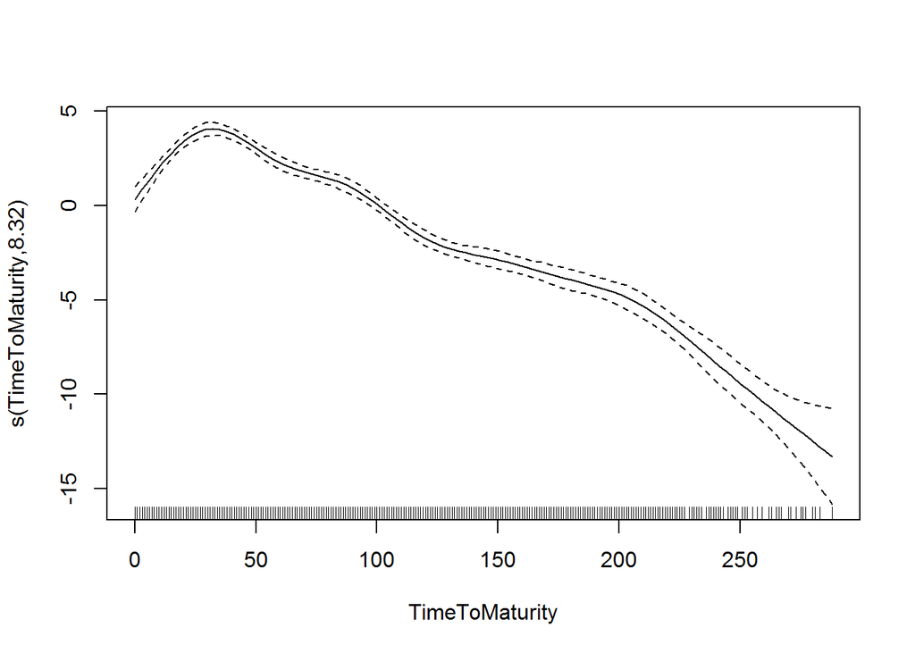

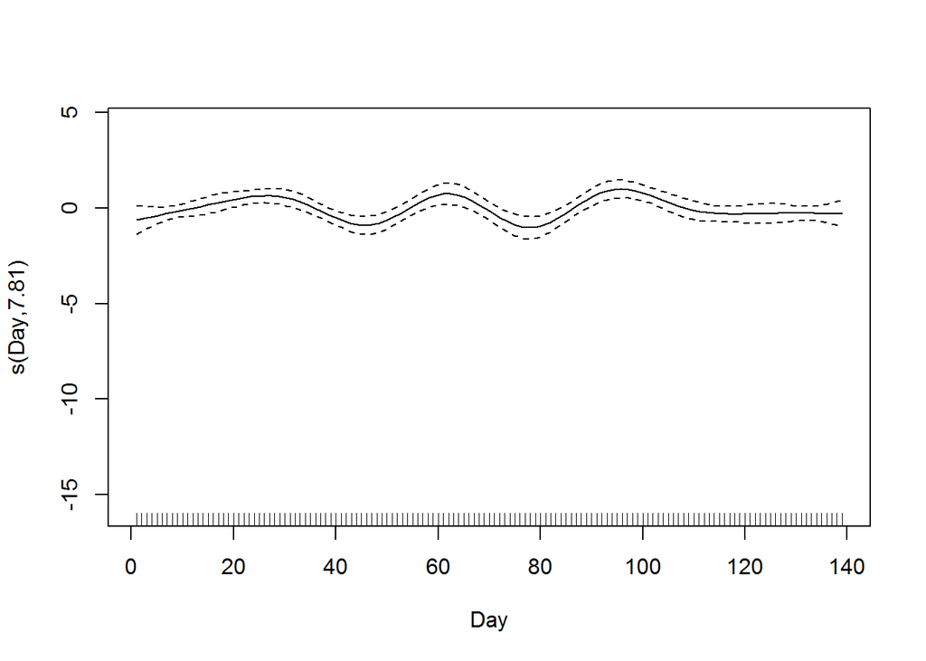

```r
plot(model2)
```

Didn’t bother graphing predictions vs actual trades since this model is so similar to the first.